# Factors That Affect The Estimated Returns - A Case Study Of Prosper Loan Data.

## by Winnie Minayo

## Investigation Overview

For this analysis, I sought to discover the factors that affect the estimated returns for the prosper company. The major factors that were investigated were the borrower APR and borrower rate.

## Dataset Overview

The prosper loan dataset is one that contains the loan information of the prosper organisation. The data ranges from the details of people who have taken loans, the amount of loans taken, those paid and unpaid, and the returns of the organisation.It consists of 113,937 rows and 81 columns.

### Distribution of Estimated Returns.

The estimated returns variable is normally distributed with majority of the returns ranging between 0.05 to 0.15.

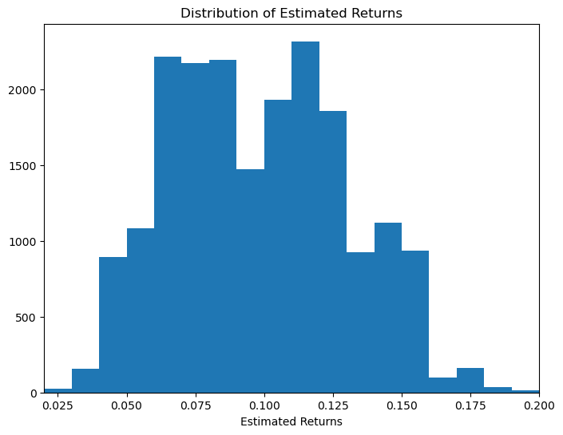

### Distribution of Borrower APR.

The distribution of borrower apr is normaly distributed with a high concentration at a range of 0.1 to 0.35 where a spike occures.

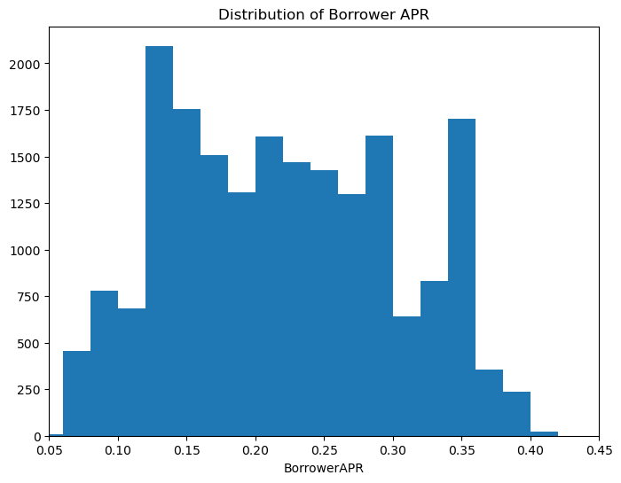

### Distribution of Borrower Rate.

The borrower rate distribution appears is similar to the borrower apr distribution. Both have a normal distribution with a spike at the values close to 0.3. This means that the rates of APR and borrower interest rates on the loans borrowed are close in range.

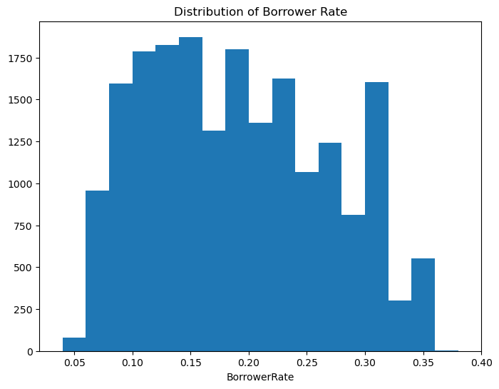

### How does the borrower rate relate to estimated return?

There is a positive correlation between the two variables. High estimated returns are associated with high borrower rates.

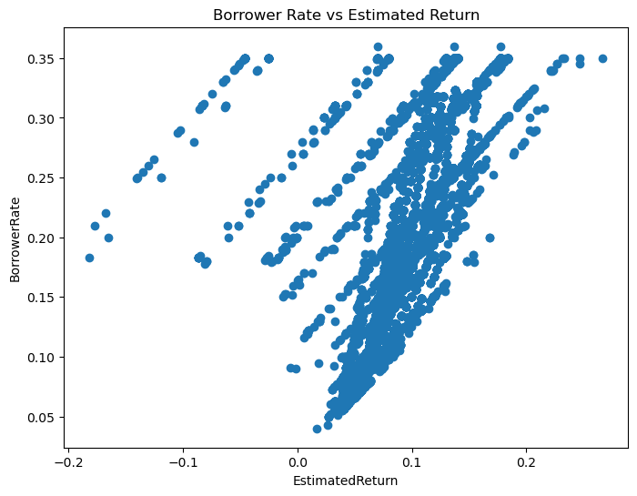

### How is the borrower rate and borrower apr affect the estimated return?

The borrower rate and borrower apr all show a positive correlation to estimated returns. An increase in the two variables means an increase in the expected returns.

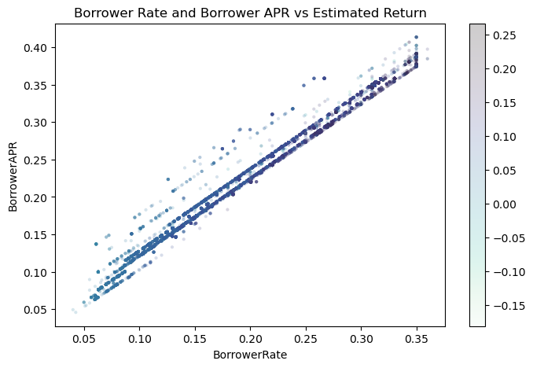